# R programming coursework

2228202

2022-11-28

# 1 Install

```r
install.packages("tidyverse")
install.packages("ggplot2")
install.packages("rstatix")
install.packages("ggpubr")
install.packages("knitr")
install.packages("performance")
install.packages("interactions")
install.packages("jtools")
install.packages("wesanderson")
install.packages("vroom")
install.packages("gridExtra")
install.packages("ggh4x")
install.packages('fitdistrplus')
install.packages("glmmTMB")
install.packages("MuMIn")
install.packages("DHARMa")
```

## 1.1 Load

```r
knitr::opts_chunk$set(echo = TRUE)

library("tidyverse")
library("ggplot2")
library("rstatix")
library("ggpubr")
library("knitr")
library("performance")
library("interactions")
library("jtools")
library("wesanderson")
library("vroom")
library("gridExtra")
library("ggh4x")
library('fitdistrplus')
library("glmmTMB")
library("MuMIn")
library("DHARMa")
```

# 2 Introduction

Investigate if summer NAO (sNAO) has an effect on body mass of *Ovis aries* and determine other factors.

## 2.1 Hypothesis

- Null - The sNAO has no effect on body mass within the population.
- Alternative - NAO and sNAO determines weight within the population.

# 3 EDA

## 3.1 Import

```r
#Vroom package to load data.

#sets wd to location of rmd file R studio only not console
setwd(dirname(rstudioapi::getActiveDocumentContext()$path))


# load in zipped gz files
mass_data <- vroom("../Data/mass_fh22528.tsv.gz")
nao_data <- vroom("../Data/NAO_fh22528.tsv.gz")
```

## 3.2 Data Structure

```r
#kable function presents in a table.
knitr::kable(head(mass_data))
```

| ID | age | sex | n_babies | site | year | pop_size | weight |
| --- | --- | --- | --- | --- | --- | --- | --- |
| 9 | 0 | m | 1 | 2 | 1980 | 142 | -8.457970 |
| 107 | 0 | m | 1 | 2 | 1980 | 142 | -3.242283 |
| 111 | 0 | m | 2 | 2 | 1980 | 142 | -8.800941 |
| 156 | 0 | f | 0 | 1 | 1980 | 142 | 5.439987 |
| 217 | 0 | m | 1 | 1 | 1980 | 142 | -11.548408 |
| 277 | 0 | m | 0 | 1 | 1980 | 142 | NA |

```r
knitr::kable(head(nao_data))
```

| year | month | NAO |
| --- | --- | --- |
| 1980 | January | 1.1580276 |
| 1980 | February | 0.9223638 |
| 1980 | March | 1.0678656 |
| 1980 | April | 1.0092662 |
| 1980 | May | 0.8724799 |
| 1980 | June | -1.4810281 |

```r
# view the data types
dplyr::glimpse(mass_data)
```

```
## Rows: 7,000
## Columns: 8
## $ ID       <dbl> 9, 107, 111, 156, 217, 277, 356, 422, 518, 529, 531, 547, 685…
## $ age      <dbl> 0, 0, 0, 0, 0, 0, 0, 0, 0, 0, 0, 0, 0, 0, 0, 0, 0, 0, 0, 1, 0…
## $ sex      <chr> "m", "m", "m", "f", "m", "m", "f", "m", "f", "f", "f", "f", "…
## $ n_babies <dbl> 1, 1, 2, 0, 1, 0, 1, 1, 1, 1, 1, 2, 2, 2, 2, 2, 0, 1, 1, 0, 0…
## $ site     <dbl> 2, 2, 2, 1, 1, 1, 2, 2, 1, 1, 1, 2, 3, 1, 2, 3, 2, 3, 2, 2, 3…
## $ year     <dbl> 1980, 1980, 1980, 1980, 1980, 1980, 1980, 1980, 1980, 1980, 1…
## $ pop_size <dbl> 142, 142, 142, 142, 142, 142, 142, 142, 142, 142, 142, 142, 1…
## $ weight   <dbl> -8.4579701, -3.2422833, -8.8009407, 5.4399872, -11.5484079, N…
```

```r
dplyr::glimpse(nao_data)
```

```
## Rows: 492
## Columns: 3
## $ year  <dbl> 1980, 1980, 1980, 1980, 1980, 1980, 1980, 1980, 1980, 1980, 1980…
## $ month <chr> "January", "February", "March", "April", "May", "June", "July", …
## $ NAO   <dbl> 1.1580276, 0.9223638, 1.0678656, 1.0092662, 0.8724799, -1.481028…
```

### 3.2.1 mass_data

- response variable - weight difference (kgs)
  - negative weight = current observation - previous observation.
- predictor variables
  - Sex
  - NAO
  - Age

### 3.2.2 nao_data

- Response variable - NAO
  - negative (low) and positive (high).
- predictor variable
  - year
  - month

## 3.3 Visualisations

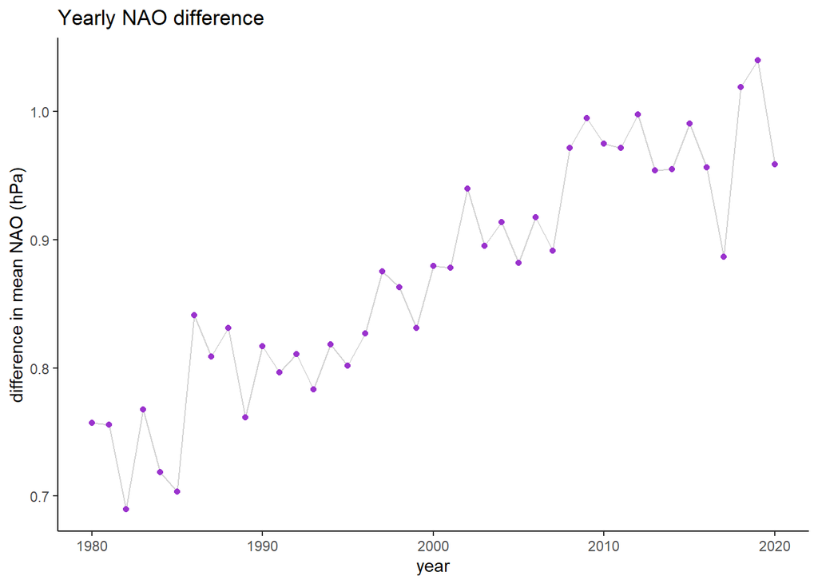

```r
# Group NAO by year
grouped_NAO <- nao_data %>%
  group_by(year) %>%
  summarise(mean_NAO = mean(NAO))

ggplot(grouped_NAO, aes(y = mean_NAO, x = year )) +
  geom_line(col = "lightgrey") +
  geom_point(col = "darkorchid3") +
  theme_classic() +
  ylab("difference in mean NAO (hPa)") +
  ggtitle("Yearly NAO difference")
```

**Figure 1.** Yearly mean NAO difference - The figure, indicates that there is a clear positive relationship between NAO and year.There is a high level of fluctuation indicated by the peaks and troughs.

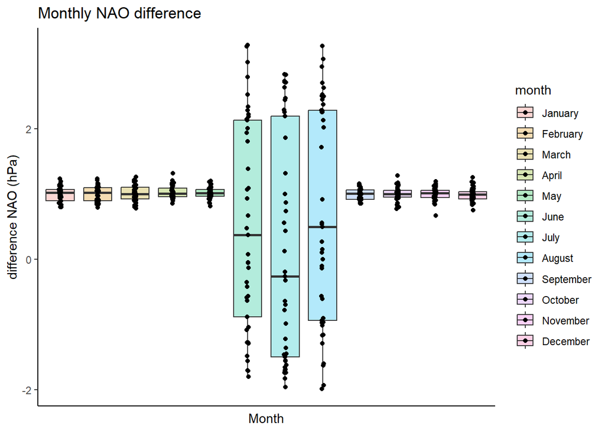

```r
#analysis of NAO data points by month

#converts month character so it can be ordered.
nao_data$month = factor(nao_data$month,levels = month.name)

# NAO difference by month - boxplot and jitter
ggplot(nao_data, aes(y = NAO,
                     x = factor(nao_data$month,levels = month.name), fill = month)) +
  geom_boxplot(alpha = 0.3, outlier.shape=NA) +
  geom_point(position=position_jitterdodge()) +
  theme_classic() +
  ylab("difference NAO (hPa)") +
  xlab("Month") +
  theme(axis.text.x=element_blank(),
        axis.ticks.x=element_blank(),
        ) +
  ggtitle("Monthly NAO difference")
```

**Figure 2.** Monthly NAO difference - This shows that NAO has much more variation within the months of June-August.

## 3.4 Mass data analysis

### 3.4.1 Check NAs

```r
#check for NA values and present results in a table

knitr::kable(mass_data %>%
  dplyr::select(everything()) %>%  #select all columns
  summarise_all(funs(sum(is.na(.)),n = n())) %>% #apply to all columns
  dplyr::select(c(1:9))) # only show 1 sample total
```

| ID_sum | age_sum | sex_sum | n_babies_sum | site_sum | year_sum | pop_size_sum | weight_sum | ID_n |
| --- | --- | --- | --- | --- | --- | --- | --- | --- |
| 0 | 0 | 0 | 0 | 0 | 0 | 0 | 667 | 7000 |

```r
knitr::kable(nao_data %>%
  dplyr::select(everything()) %>%  #select all columns
  summarise_all(funs(sum(is.na(.)),n = n())) %>% #apply to all columns
   dplyr::select(c(1:4)))# only show 1 sample total
```

| year_sum | month_sum | NAO_sum | year_n |
| --- | --- | --- | --- |
| 0 | 0 | 0 | 492 |

```r
#remove_NAs
mass_data_clean <- mass_data %>%
  dplyr::filter(!is.na(weight)) %>%  #remove NAs
  dplyr::rename(weight_diff_kg = weight)
```

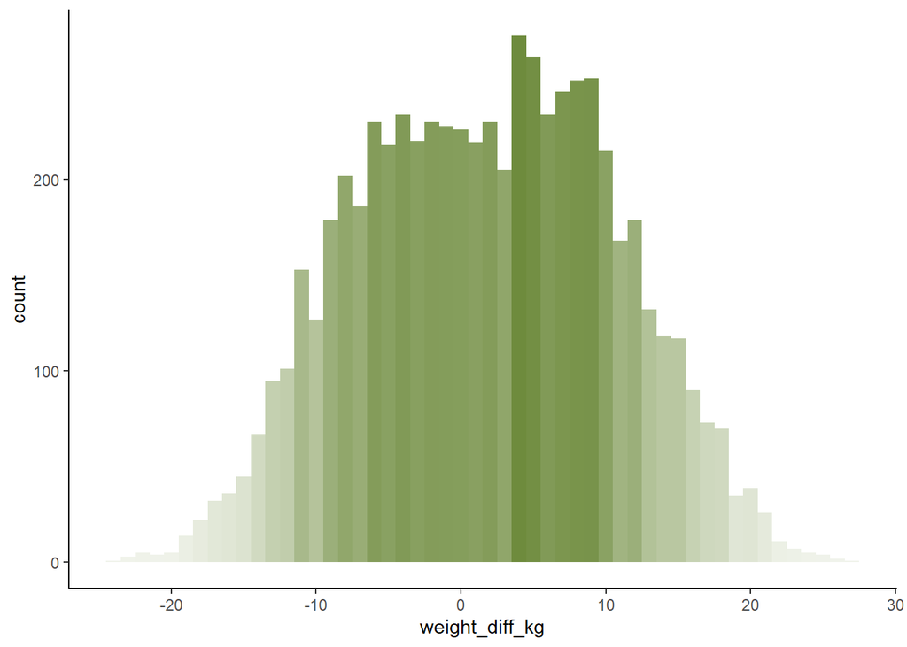

```r
# check for normal distribution of data of our response variable
ggplot(mass_data_clean, aes(x = weight_diff_kg, alpha=after_stat(count))) +
  geom_histogram(fill = "darkolivegreen4", binwidth = 1) +
  theme_classic() +
  theme(legend.position = "none")
```

**Figure 3.** Distribution of weight difference - This figure shows how weight difference has a central tendency towards 1kg.

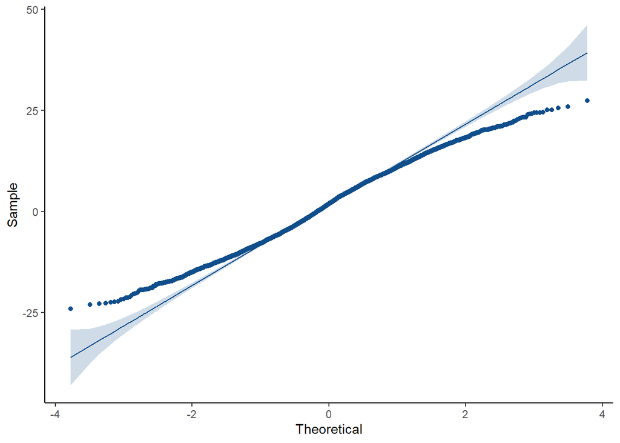

```r
ggqqplot(mass_data_clean, x = "weight_diff_kg", color = "dodgerblue4") + theme_classic()
```

**Figure 4.** Weight qqplot - At the extreme ends weight data does not fit very well to a normal distribution, it is lightly tailed.

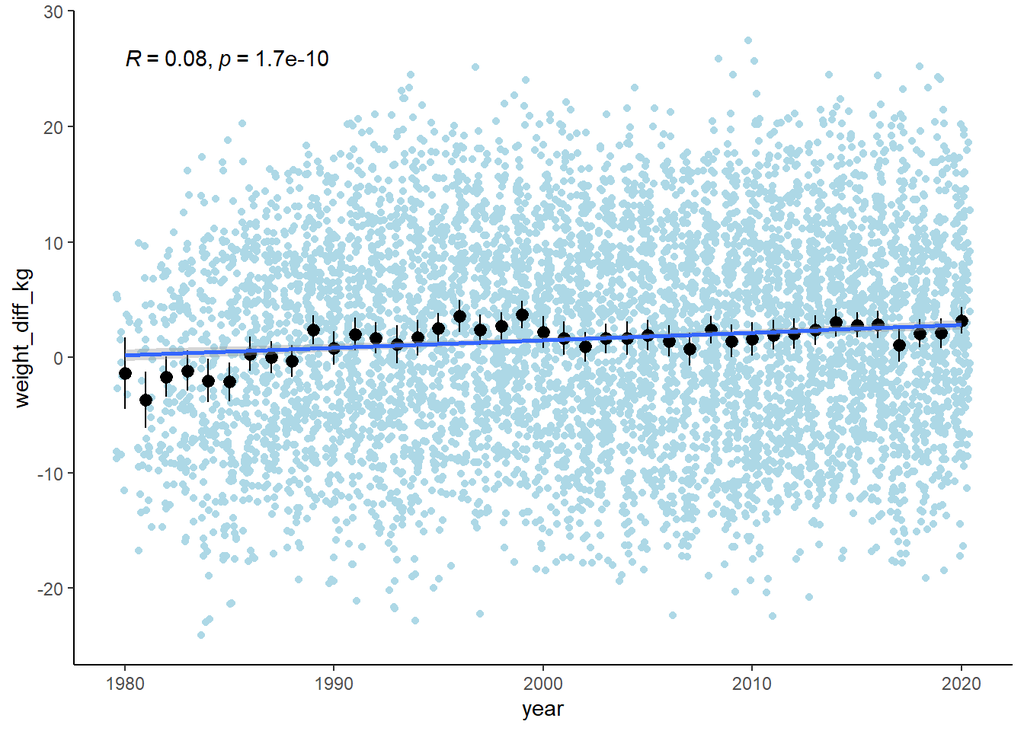

```r
# weight by year
plot_wt_year <- ggplot(mass_data_clean, aes(x= year, y = weight_diff_kg))

plot_wt_year + geom_jitter(col = "lightblue") +
  stat_summary(fun.data=mean_cl_normal) +
  geom_smooth(method='lm', formula= y~x) +
  theme_classic() +
  stat_cor(method = "pearson") +
  theme(legend.position="none")
```

**Figure 5.** Yearly weight difference - The correlation between weight and year is very low, Within the sample data there does not seem to be a decrease in weight overall within the 40 year time period. There is significant clustering at time points.

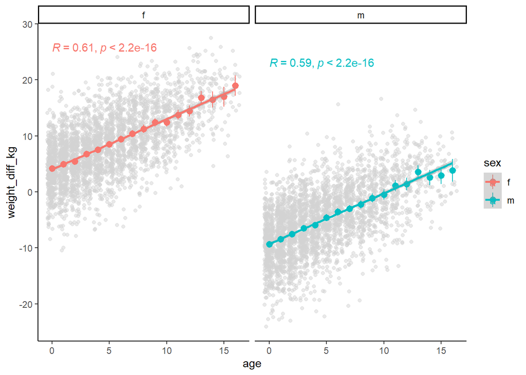

```r
# sex and age
#### ages and weight have a positive correlation.

ggplot(mass_data_clean, aes(x= age, y = weight_diff_kg, col = sex )) +
  geom_jitter(col = "lightgrey", alpha = .5) +
  stat_summary(fun.data=mean_cl_normal) +
  geom_smooth(method='lm', formula= y~x) +
  facet_grid(~sex) +
  stat_cor(method = "pearson") +
  theme_classic()
```

**Figure 6.** Weight difference by age and sex - Shows moderate positive correlations between age and weight difference for both sex groups.

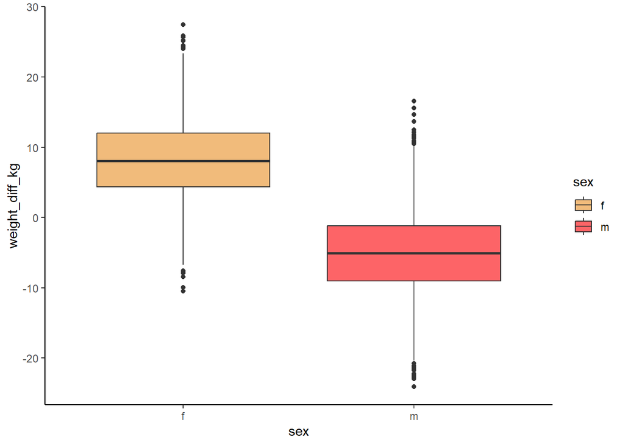

```r
#weight and sex
ggplot(mass_data_clean, aes(x= sex, y = weight_diff_kg, fill = sex)) +
  geom_boxplot() + theme_classic() +
  scale_fill_manual(values = wes_palette("GrandBudapest1"))+
  scale_color_manual(values = wes_palette("GrandBudapest1"))
```

**Figure 7.** Sex and weight difference - The difference in mean weight between the male and female groups.

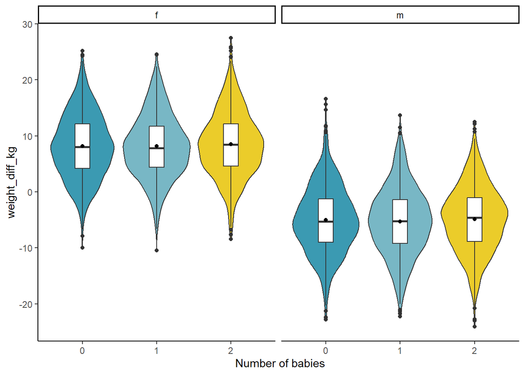

```r
#weight, n_babies, facet by sex
ggplot(mass_data_clean, aes(x = as.factor(n_babies), y = weight_diff_kg, fill = as.factor(n_babies))) +
  geom_violin() +
  geom_boxplot(width=0.2, fill = "white") +
  facet_grid(~ sex) +
  theme_classic() +
  scale_fill_manual(values = wes_palette("Zissou1"))+
  scale_color_manual(values = wes_palette("Zissou1")) +
  xlab(" Number of babies") +
  stat_summary( fun = mean, geom="point") +
  theme(legend.position="none")
```

**Figure 8.** Number of babies and weight difference - The number of babies does not influence a difference in weight.

- **Summary** - age and sex are interesting variables

# 4 Data transformation

## 4.1 Yearly grouping & join

```r
## grouped mass data ##
# the NAO data is yearly and monthly, so lets aggregate the mass data to match it

grouped_mass <- mass_data %>%
  dplyr::group_by(year) %>%
  dplyr::filter(!is.na(weight)) %>%   #remove NAs
  summarise(mean_weight_diff_kg = mean(weight))
```

```r
#view the transformation
knitr::kable(head(grouped_mass))
```

| year | mean_weight_diff_kg |
| --- | --- |
| 1980 | -1.376821 |
| 1981 | -3.696238 |
| 1982 | -1.682028 |
| 1983 | -1.153579 |
| 1984 | -2.012490 |
| 1985 | -2.136328 |

```r
# Join yearly mass to yearly NAO data.
grouped_mass_NAO <- dplyr::left_join(grouped_mass, grouped_NAO,
                                     by = c("year"= "year"))
#view the transformation
knitr::kable(head(grouped_mass_NAO))
```

| year | mean_weight_diff_kg | mean_NAO |
| --- | --- | --- |
| 1980 | -1.376821 | 0.7571645 |
| 1981 | -3.696238 | 0.7555329 |
| 1982 | -1.682028 | 0.6899372 |
| 1983 | -1.153579 | 0.7676807 |
| 1984 | -2.012490 | 0.7185351 |
| 1985 | -2.136328 | 0.7036301 |

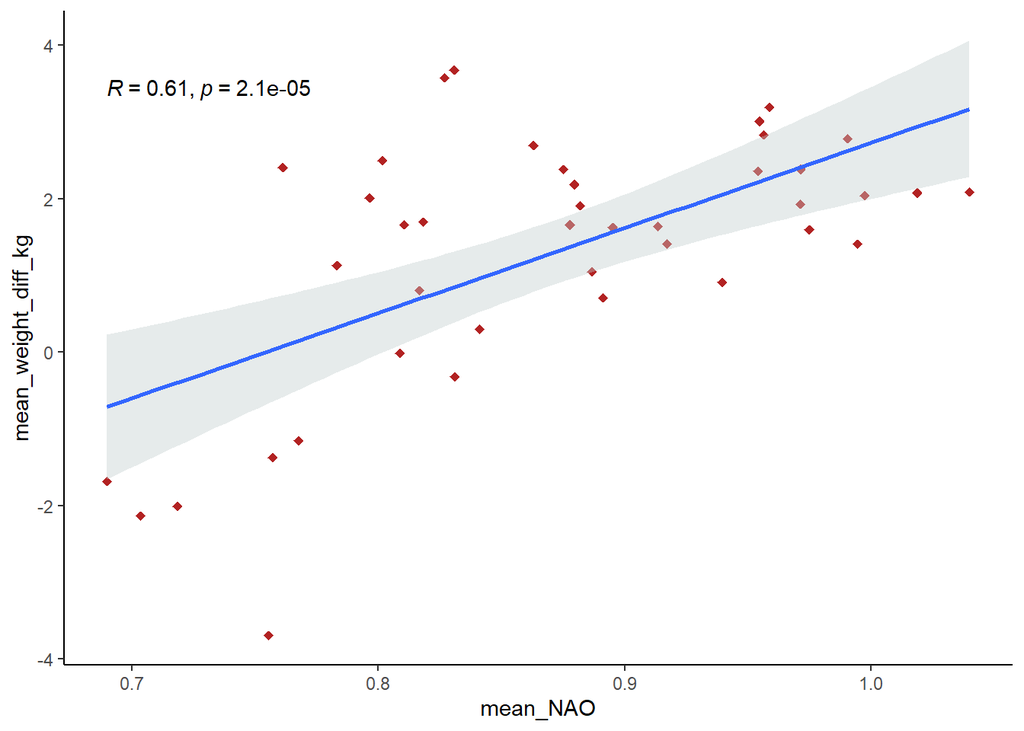

```r
# a plot of the yearly weight difference variable (y) against yearly mean_NAO (x)
ggplot(data = grouped_mass_NAO, aes(x = mean_NAO, y = mean_weight_diff_kg)) +
  geom_point(color = "firebrick",shape = "diamond", size = 2) +
  geom_smooth(method='lm', formula= y~x, fill = "azure3") +
  stat_cor(method = "pearson") +
  theme_classic() +
  theme(legend.position = "none")
```

**Figure 9.** Comparing yearly weight and NAO - There does seem to be a moderate positive relationship between yearly mean NAO and yearly weight difference.

## 4.2 Creating a summer NAO category.

The difference in Figure 2. justifies creating a new variable sNAO category.

```r
#### lets try to create a summer categorical variable to group by ###
## 28/12/2022

#filter for the summer months with increased NAO variation
summer_filter <- c("June", "July", "August")

### creating a category of sNAO and not sNAO for visualisaton
seasonal_nao_data <- nao_data %>%
  mutate(nao_type = case_when(month %in% summer_filter ~ "summer_NAO", #in summer
                              !month %in% summer_filter ~ "not_summer_NAO")) %>% #not in summer
  group_by(year,nao_type) %>%
  summarise(mean_nao = mean(NAO))
knitr::kable(head(seasonal_nao_data))
```

| year | nao_type | mean_nao |
| --- | --- | --- |
| 1980 | not_summer_NAO | 1.0074401 |
| 1980 | summer_NAO | 0.0063377 |
| 1981 | not_summer_NAO | 0.9907959 |
| 1981 | summer_NAO | 0.0497437 |
| 1982 | not_summer_NAO | 0.9312786 |
| 1982 | summer_NAO | -0.0340871 |

```r
# Joining the data in the same manner with the new category.
# create a yearly mass and joined it to yearly NAO data.
grouped_mass_NAO_seasonal <- dplyr::left_join(grouped_mass, seasonal_nao_data,
                                                 by = c("year"= "year"))

knitr::kable(head(grouped_mass_NAO_seasonal))
```

| year | mean_weight_diff_kg | nao_type | mean_nao |
| --- | --- | --- | --- |
| 1980 | -1.376821 | not_summer_NAO | 1.0074401 |
| 1980 | -1.376821 | summer_NAO | 0.0063377 |
| 1981 | -3.696238 | not_summer_NAO | 0.9907959 |
| 1981 | -3.696238 | summer_NAO | 0.0497437 |
| 1982 | -1.682028 | not_summer_NAO | 0.9312786 |
| 1982 | -1.682028 | summer_NAO | -0.0340871 |

# 5 Data Visualisation

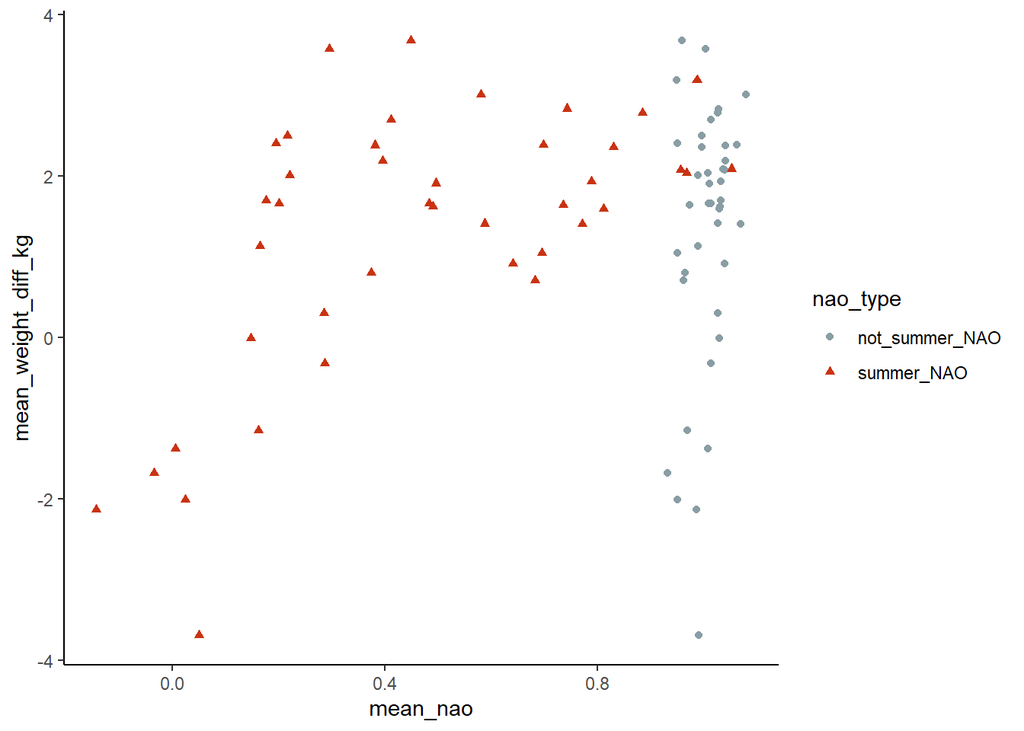

```r
#point data
ggplot(data = grouped_mass_NAO_seasonal,
       aes(x = mean_nao,y = mean_weight_diff_kg, colour = nao_type, shape =nao_type )) +
  geom_point() + theme_classic() +
   scale_fill_manual(values = wes_palette("Royal1"))+
  scale_color_manual(values = wes_palette("Royal1"))
```

**Figure 10** Seasonal yearly weight by NAO - This figure now shows a moderate positive correlation between mean_nao and mean_weight. As the yearly mean NAO variation increases, the mean weight difference increases. However, the not summer NAO grouping does not follow this pattern with differences between the two groups.

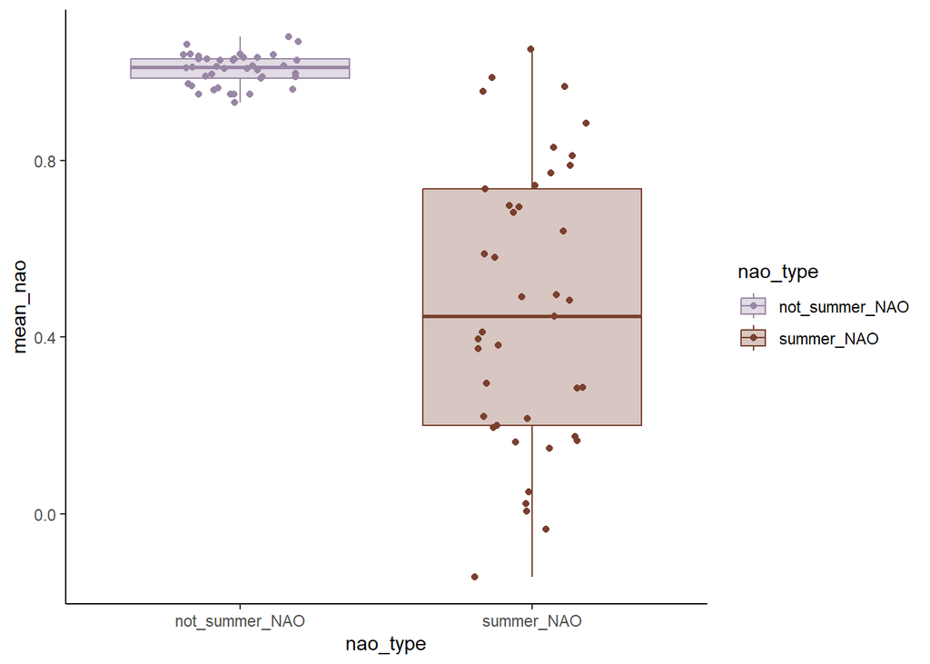

```r
boxplot <- ggplot(grouped_mass_NAO_seasonal, aes (x= nao_type ,
                                                  y=mean_nao, fill = nao_type, col =nao_type))


boxplot +
  geom_boxplot(alpha = 0.3, outlier.shape=NA) +
  geom_point(position=position_jitterdodge()) +
  theme_classic() +
  scale_fill_manual(values = wes_palette("IsleofDogs1"))+
  scale_color_manual(values = wes_palette("IsleofDogs1"))
```

**Figure 11.** Seasonal means of NAO differences - Grouping is more concise than trying to interpret each month as a category.

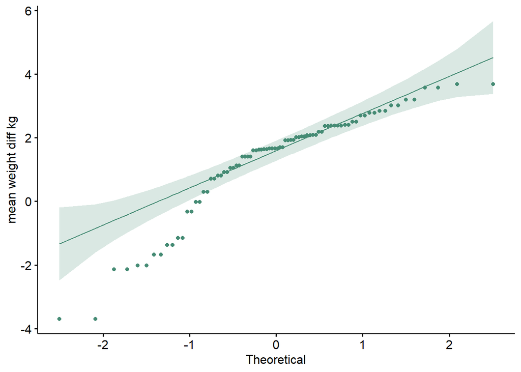

```r
ggqqplot(grouped_mass_NAO_seasonal, x="mean_weight_diff_kg", ylab = "mean weight diff kg", col = "aquamarine4")
```

**Figure 12.** Yearly weight distribution - There is some left skew.

## 5.1 Correlation

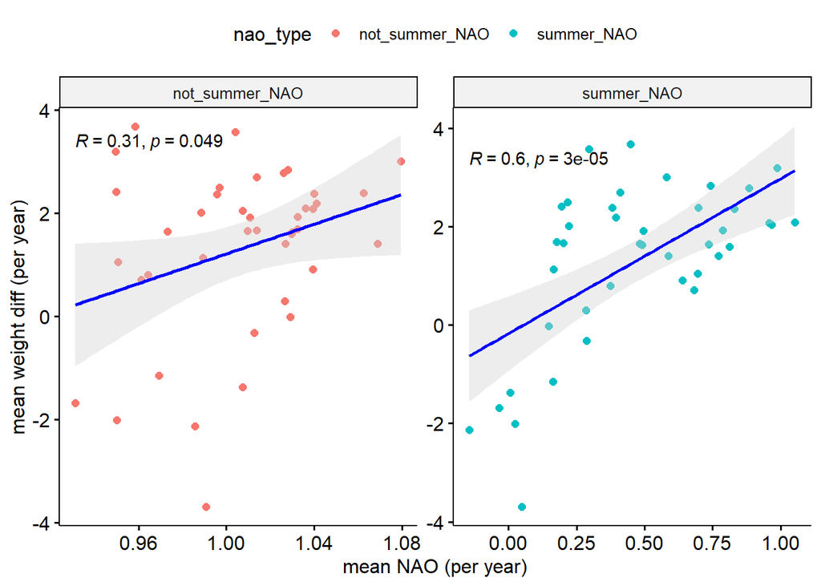

```r
## Correlation analysis between weight and NAO.

ggscatter(grouped_mass_NAO_seasonal, x = "mean_nao", y = "mean_weight_diff_kg",
          color = "nao_type",
          add = "reg.line", conf.int = TRUE,
          add.params = list(color = "blue", fill = "lightgray"),
          cor.coef = TRUE, cor.method = "pearson",
          ylab = "mean weight diff (per year)", xlab = "mean NAO (per year)"
          ) + facet_wrap2(~nao_type,  scales = "free") #new package to facet scales differently
```

# 6 Generalised linear models (GLMs)

## 6.1 Transformation before GLMs

Examine casual relationships.

- Variables of interest.
  - summer NAO
  - year
  - age
  - sex

```r
## A final data transformation brings the variables of interest together.

# predictors, sex, age, nao type  and year.

grp_mass_predictors <- mass_data %>%
  dplyr::group_by(year, age, sex) %>% #grouping by highest correlated predictors
  dplyr::filter(!is.na(weight)) %>%   #remove NAs
  dplyr::rename(age_yrs = age) %>% #add in units of measure.
  summarise(mean_weight_diff_kg = mean(weight)) # mean weight difference per year
# join in NAO type data.
grp_mass_pred_NAO <- dplyr::left_join(grp_mass_predictors, seasonal_nao_data,
                                     by = c("year"= "year"))
```

```r
#view the transformation
head(grp_mass_pred_NAO) %>% kable()
```

| year | age_yrs | sex | mean_weight_diff_kg | nao_type | mean_nao |
| --- | --- | --- | --- | --- | --- |
| 1980 | 0 | f | 3.105356 | not_summer_NAO | 1.0074401 |
| 1980 | 0 | f | 3.105356 | summer_NAO | 0.0063377 |
| 1980 | 0 | m | -5.298725 | not_summer_NAO | 1.0074401 |
| 1980 | 0 | m | -5.298725 | summer_NAO | 0.0063377 |
| 1981 | 0 | f | 3.442493 | not_summer_NAO | 0.9907959 |
| 1981 | 0 | f | 3.442493 | summer_NAO | 0.0497437 |

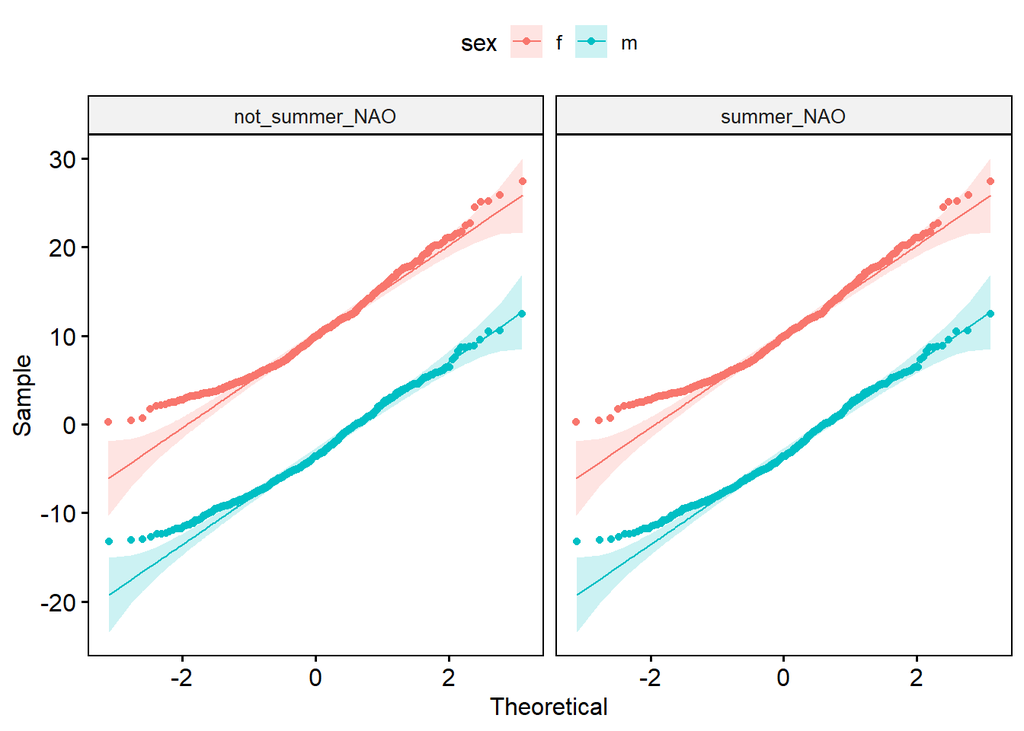

```r
#check for normality
ggqqplot(grp_mass_pred_NAO, x = "mean_weight_diff_kg", color = "sex", facet.by = "nao_type")
```

**Figure 14.** Checking for normality in NAO type -

## 6.2 Deciding distributions

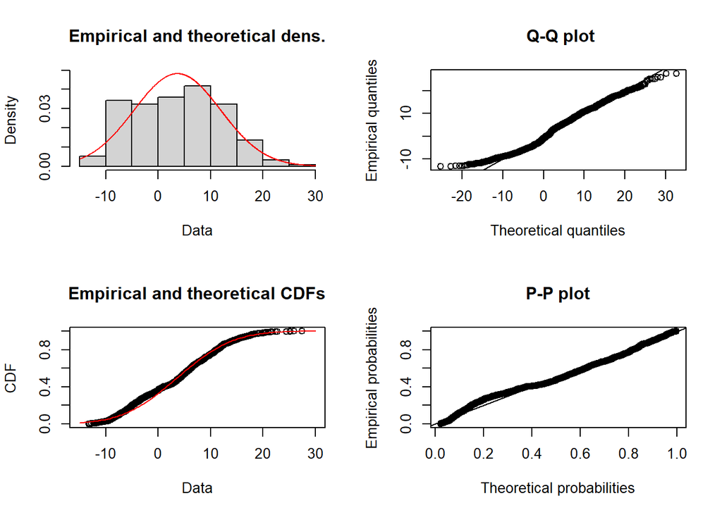

```r
#check oberserved weigth differences, against the normal distribution.
plot(fitdist(grp_mass_pred_NAO$mean_weight_diff_kg, "norm"))
```

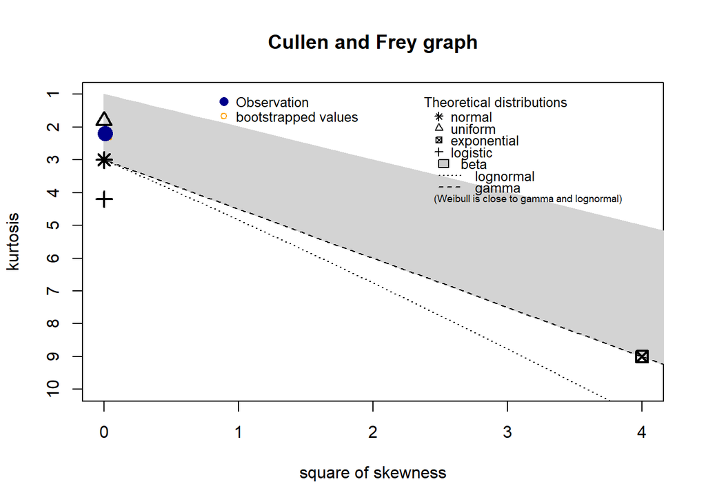

```
## summary statistics
## ------
## min:  -13.22516   max:  27.44608
## median:  4.255518
## mean:  3.656375
## estimated sd:  8.284229
## estimated skewness:  0.09430417
## estimated kurtosis:  2.191653
```

```r
#summary statistics, skewness is low.
descdist(grp_mass_pred_NAO$mean_weight_diff_kg, boot = 1000)
```

**Figure 15.** Fitdist the normal distribution - The normal distribution can be used in the model,there are negative values which limit other families.

## 6.3 Creating Models

```r
# predictors - mean_nao

mod1 <- glm(mean_weight_diff_kg ~ mean_nao,
            data = grp_mass_pred_NAO,
            family = "gaussian")

# predictors mean nao, and sex
mod2 <- glm(mean_weight_diff_kg ~ mean_nao + sex,
              data = grp_mass_pred_NAO,
              family = "gaussian")


# predictors mean nao, and sex interacting with age
mod3 <- glm(mean_weight_diff_kg ~ mean_nao + age_yrs * sex,
            data = grp_mass_pred_NAO,
            family = "gaussian")

# null model for comparison
null_mod <- glm(mean_weight_diff_kg ~ 1,
            data = grp_mass_pred_NAO,
            family = "gaussian")



# predictors age interaction with sex (added after output analysis)
mod3.1 <- glm(mean_weight_diff_kg ~ age_yrs + sex,
            data = grp_mass_pred_NAO,
            family = "gaussian")


# predictors  age and sex without interaction  (added after output analysis)
mod3.2 <- glm(mean_weight_diff_kg ~ mean_nao + sex + age_yrs,
            data = grp_mass_pred_NAO,
            family = "gaussian")


# predictors mean nao and  nao_type type
mod4 <- glm(mean_weight_diff_kg ~ mean_nao + nao_type,
            data = grp_mass_pred_NAO,
            family = "gaussian")

# predictors - sex, age and type- give some interactions
mod5 <- glm(mean_weight_diff_kg ~ mean_nao + mean_nao:sex,
            data = grp_mass_pred_NAO,
            family = "gaussian")

# predictors - sex, age and type- give some interactions
mod6 <- glm(mean_weight_diff_kg ~ mean_nao + sex:nao_type,
            data = grp_mass_pred_NAO,
            family = "gaussian")
```

## 6.4 Assessing model fit

```r
# The performance package can compare models
compare_performance(mod1, mod2, mod3, mod4, mod5, mod6) %>% kable()
```

| Name | Model | AIC | AIC_wt | AICc | AICc_wt | BIC | BIC_wt | R2 | RMSE | Sigma |
| --- | --- | --- | --- | --- | --- | --- | --- | --- | --- | --- |
| mod1 | glm | 15095.24 | 0 | 15095.25 | 0 | 15112.24 | 0 | 0.0018633 | 8.274570 | 8.278447 |
| mod2 | glm | 12820.46 | 0 | 12820.48 | 0 | 12843.13 | 0 | 0.6562271 | 4.856084 | 4.859498 |
| mod3 | glm | 10032.83 | 1 | 10032.87 | 1 | 10066.83 | 1 | 0.9069592 | 2.526313 | 2.529275 |
| mod4 | glm | 15091.95 | 0 | 15091.97 | 0 | 15114.61 | 0 | 0.0043336 | 8.264324 | 8.270134 |
| mod5 | glm | 13296.23 | 0 | 13296.25 | 0 | 13318.90 | 0 | 0.5704566 | 5.428176 | 5.431992 |
| mod6 | glm | 12810.81 | 0 | 12810.85 | 0 | 12844.81 | 0 | 0.6584169 | 4.840594 | 4.846269 |

```r
compare_performance(mod1, mod2, mod3, mod4, mod5,mod6, rank = TRUE) %>% kable()
```

| Name | Model | R2 | RMSE | Sigma | AIC_wt | AICc_wt | BIC_wt | Performance_Score |
| --- | --- | --- | --- | --- | --- | --- | --- | --- |
| mod3 | glm | 0.9069592 | 2.526313 | 2.529275 | 1 | 1 | 1 | 1.0000000 |
| mod6 | glm | 0.6584169 | 4.840594 | 4.846269 | 0 | 0 | 0 | 0.3199629 |
| mod2 | glm | 0.6562271 | 4.856084 | 4.859498 | 0 | 0 | 0 | 0.3187270 |
| mod5 | glm | 0.5704566 | 5.428176 | 5.431992 | 0 | 0 | 0 | 0.2697492 |
| mod4 | glm | 0.0043336 | 8.264324 | 8.270134 | 0 | 0 | 0 | 0.0009929 |
| mod1 | glm | 0.0018633 | 8.274570 | 8.278447 | 0 | 0 | 0 | 0.0000000 |

**Table 1.** - A summary of GLM model formulas and ranking.

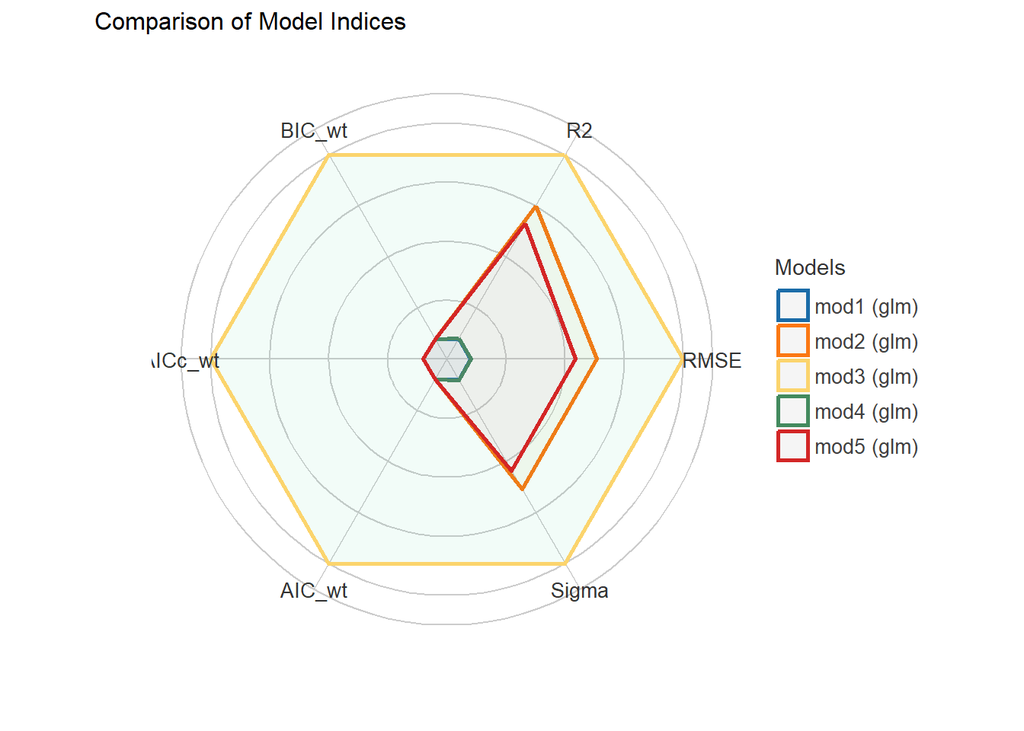

```r
plot(compare_performance(mod1, mod2, mod3, mod4, mod5, rank = TRUE))
```

```r
#Checking for heteroscedasticity
check_heteroscedasticity(mod3)
check_heteroscedasticity(mod3.2)
check_heteroscedasticity(mod6)
```

[output not shown]

```
## OK: Error variance appears to be homoscedastic (p = 0.655).
```

## 6.5 Model output

```r
summary(mod3)
```

```
##
## Call:
## glm(formula = mean_weight_diff_kg ~ mean_nao + age_yrs * sex,
##     family = "gaussian", data = grp_mass_pred_NAO)
##
## Deviance Residuals:
##      Min        1Q    Median        3Q       Max
## -12.1074   -1.4314    0.0222    1.3489   10.8359
##
## Coefficients:
##                Estimate Std. Error t value Pr(>|t|)
## (Intercept)    4.126946   0.191228  21.581   <2e-16 ***
## mean_nao      -0.210313   0.179633  -1.171    0.242
## age_yrs        0.907132   0.016516  54.926   <2e-16 ***
## sexm         -13.169075   0.196345 -67.071   <2e-16 ***
## age_yrs:sexm  -0.009812   0.023721  -0.414    0.679
## ---
## Signif. codes:  0 '***' 0.001 '**' 0.01 '*' 0.05 '.' 0.1 ' ' 1
##
## (Dispersion parameter for gaussian family taken to be 6.397231)
##
##     Null deviance: 146522  on 2135  degrees of freedom
## Residual deviance:  13632  on 2131  degrees of freedom
## AIC: 10033
##
## Number of Fisher Scoring iterations: 2
```

- **coefficients**

The age_yrs variable has a p-value < 0.05, which suggests age affects the weight response variable. The interaction between sex and age is not significant.

- **Null and residual deviance**

There is a large decrease in residual deviance compared to the null deviance suggesting the predictors have influence on weight. A limitation is the residual deviance is high when compared to the residual degrees of freedom.

```r
# comparing deviance of models by order of ranking.

anova(mod1, mod2, mod3, mod6, test = "Chisq")
```

```
## Analysis of Deviance Table
##
## Model 1: mean_weight_diff_kg ~ mean_nao
## Model 2: mean_weight_diff_kg ~ mean_nao + sex
## Model 3: mean_weight_diff_kg ~ mean_nao + age_yrs * sex
## Model 4: mean_weight_diff_kg ~ mean_nao + sex:nao_type
##   Resid. Df Resid. Dev Df Deviance  Pr(>Chi)
## 1      2134     146249
## 2      2133      50370  1    95879 < 2.2e-16 ***
## 3      2131      13632  2    36738 < 2.2e-16 ***
## 4      2131      50049  0   -36417
## ---
## Signif. codes:  0 '***' 0.001 '**' 0.01 '*' 0.05 '.' 0.1 ' ' 1
```

```r
#How does the model look without the NAO variable as a predictor?
anova(mod3, mod3.1 ,test= "Chisq")
```

```
## Analysis of Deviance Table
##
## Model 1: mean_weight_diff_kg ~ mean_nao + age_yrs * sex
## Model 2: mean_weight_diff_kg ~ age_yrs + sex
##   Resid. Df Resid. Dev Df Deviance Pr(>Chi)
## 1      2131      13632
## 2      2133      13642 -2  -9.8524    0.463
```

```r
# lets also compare predictors against a null model
anova(mod3, null_mod, test= "Chisq")
```

```
## Analysis of Deviance Table
##
## Model 1: mean_weight_diff_kg ~ mean_nao + age_yrs * sex
## Model 2: mean_weight_diff_kg ~ 1
##   Resid. Df Resid. Dev Df Deviance  Pr(>Chi)
## 1      2131      13632
## 2      2135     146522 -4  -132889 < 2.2e-16 ***
## ---
## Signif. codes:  0 '***' 0.001 '**' 0.01 '*' 0.05 '.' 0.1 ' ' 1
```

```r
# computes a statistically significant p-value for chi-squared and formats the output better.
summ(mod3, confint = TRUE)
```

| Observations | 2136 |
| --- | --- |
| Dependent variable | mean_weight_diff_kg |
| Type | Linear regression |

| χ²(4) | 132889.25 |
| --- | --- |
| Pseudo-R² (Cragg-Uhler) | 0.91 |
| Pseudo-R² (McFadden) | 0.34 |
| AIC | 10032.83 |
| BIC | 10066.83 |

|  | Est. | 2.5% | 97.5% | t val. | p |
| --- | --- | --- | --- | --- | --- |
| (Intercept) | 4.13 | 3.75 | 4.50 | 21.58 | 0.00 |
| mean_nao | -0.21 | -0.56 | 0.14 | -1.17 | 0.24 |
| age_yrs | 0.91 | 0.87 | 0.94 | 54.93 | 0.00 |
| sexm | -13.17 | -13.55 | -12.78 | -67.07 | 0.00 |
| age_yrs:sexm | -0.01 | -0.06 | 0.04 | -0.41 | 0.68 |

Standard errors: MLE

```r
export_summs(mod3)
```

|  | Model 1 |
| --- | --- |
| (Intercept) | 4.13 *** |
|  | (0.19) |
| mean_nao | -0.21 |
|  | (0.18) |
| age_yrs | 0.91 *** |
|  | (0.02) |
| sexm | -13.17 *** |
|  | (0.20) |
| age_yrs:sexm | -0.01 |
|  | (0.02) |
| N | 2136 |
| AIC | 10032.83 |
| BIC | 10066.83 |
| Pseudo R2 | 0.91 |
| *** p < 0.001; ** p < 0.01; * p < 0.05. |  |

## 6.6 Predicted vs observed

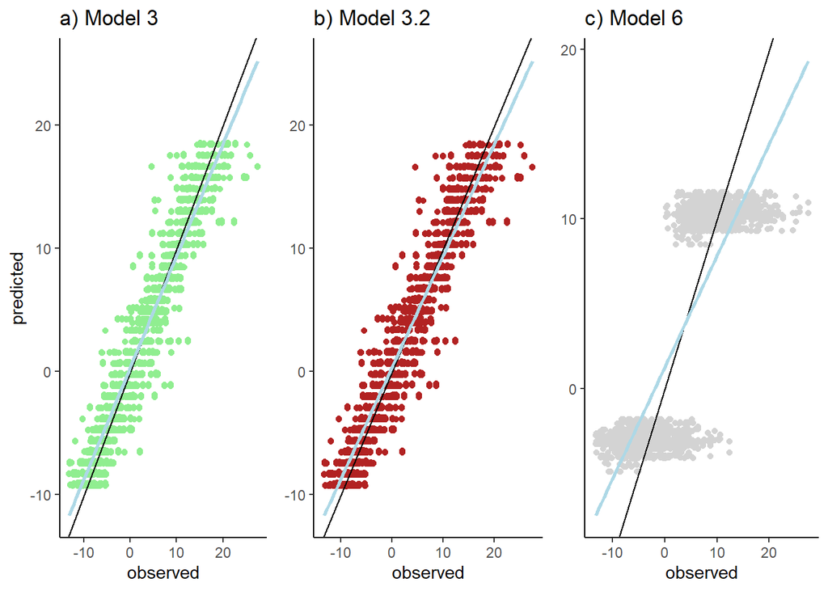

```r
#Lets compare predicted vs observed values from some promising models.


#model 3
##visualize the fitted vs observed values for model 3
fit_data3 <- data.frame("predicted"= mod3$fitted.values,
                       "observed" = grp_mass_pred_NAO$mean_weight_diff_kg)
##plot them
po1 <- ggplot(fit_data3, aes(x=observed, y=predicted)) +
  geom_point(col = "lightgreen") +
  ##add a 1:1 line
  geom_abline(intercept = 0) +
  ##add a linear regression to your data
  geom_smooth(method="lm",
              col="lightblue",
              se = F) +
  #colour adjustment
  ##set the theme
  theme_classic() +
  theme(legend.position="none") +
  ggtitle("a) Model 3")



#model 3.2 without interactions
##visualize the fitted vs observed values for model 3
fit_data_3.2 <- data.frame("predicted"= mod3.2$fitted.values,
                       "observed" = grp_mass_pred_NAO$mean_weight_diff_kg)
##plot them
po2 <- ggplot(fit_data_3.2, aes(x=observed, y=predicted)) +
  geom_point(col = "firebrick") +
  ##add a 1:1 line
  geom_abline(intercept = 0) +
  ##add a linear regression to your data
  geom_smooth(method="lm",
              col="lightblue",
              se = F) +
  #colour adjustment
  ##set the theme
  theme_classic() +
  theme(legend.position="none" ) +
  ggtitle("b) Model 3.2") +
  theme(axis.title.y =element_blank()) # remove dup axis


#model 6

#model 3.2 without interactions
##visualize the fitted vs observed values for model 3
fit_data_6 <- data.frame("predicted"= mod6$fitted.values,
                       "observed" = grp_mass_pred_NAO$mean_weight_diff_kg)
##plot them
po3 <- ggplot(fit_data_6, aes(x=observed, y=predicted)) +
  geom_point(col = "lightgrey") +
  ##add a 1:1 line
  geom_abline(intercept = 0) +
  ##add a linear regression to your data
  geom_smooth(method="lm",
              col="lightblue",
              se = F) +
  ##set the theme
  theme_classic() +
  theme(legend.position="none") +
  ggtitle("c) Model 6") +
  theme(axis.title.y =element_blank()) # remove dup axis


grid.arrange(po1,po2,po3, nrow = 1)
```

**Figure 17.** Predicted vs bbserved weight values -

## 6.7 visualising the models

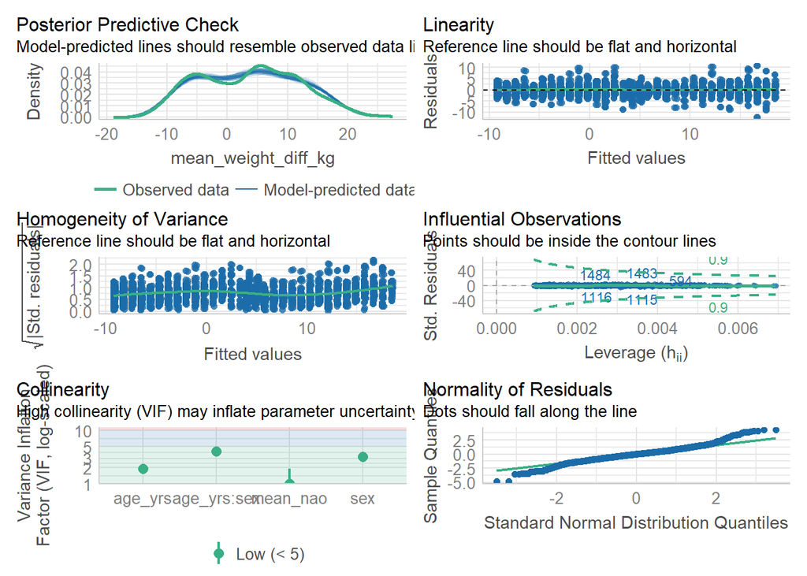

```r
check_model(mod3)
```

## 6.8 Plotting coefficients

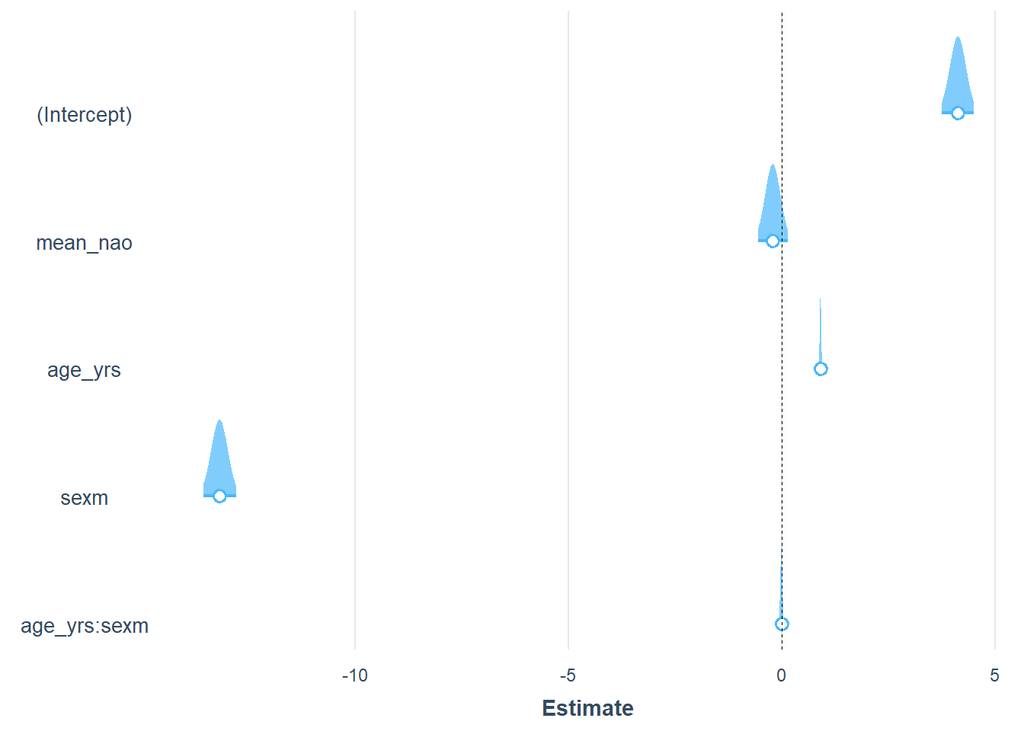

```r
# Plot the coefficients, shows the distance between males and females

plot_summs(mod3,
           omit.coefs = NULL,
           plot.distributions = TRUE ,rescale.distributions = TRUE, scale = FALSE)
```

**Figure 19.** Model 3 coefficients plot - The sexm variable coefficient estimate is very far from sexf at the intercept.

## 6.9 Interactions

```r
summary(mod6)
```

```
##
## Call:
## glm(formula = mean_weight_diff_kg ~ mean_nao + sex:nao_type,
##     family = "gaussian", data = grp_mass_pred_NAO)
##
## Deviance Residuals:
##      Min        1Q    Median        3Q       Max
## -10.4498   -3.7166   -0.4916    3.1808   17.1167
##
## Coefficients: (1 not defined because of singularities)
##                             Estimate Std. Error t value Pr(>|t|)
## (Intercept)                  -4.5199     0.3553 -12.721  < 2e-16 ***
## mean_nao                      2.5577     0.5225   4.895 1.05e-06 ***
## sexf:nao_typenot_summer_NAO  12.2155     0.3831  31.885  < 2e-16 ***
## sexm:nao_typenot_summer_NAO  -1.1863     0.3843  -3.087  0.00205 **
## sexf:nao_typesummer_NAO      13.3935     0.2966  45.155  < 2e-16 ***
## sexm:nao_typesummer_NAO           NA         NA      NA       NA
## ---
## Signif. codes:  0 '***' 0.001 '**' 0.01 '*' 0.05 '.' 0.1 ' ' 1
##
## (Dispersion parameter for gaussian family taken to be 23.48632)
##
##     Null deviance: 146522  on 2135  degrees of freedom
## Residual deviance:  50049  on 2131  degrees of freedom
## AIC: 12811
##
## Number of Fisher Scoring iterations: 2
```

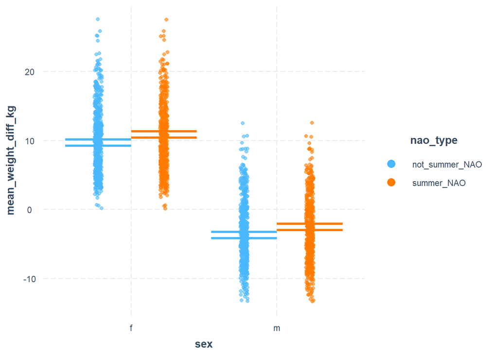

```r
#interaction between sex and nao_type
cat_plot(mod6,
              pred = sex,
              modx = nao_type,
              plot.points = TRUE)
```

**Figure 20.1.** - Interaction summer and weight.

```r
# lets explore model any interactions between year and NAO


# do NAO and year interact?

mod6.3 <- glm(mean_weight_diff_kg ~ mean_nao * year,
            data = grp_mass_pred_NAO,
            family = "gaussian")

#summary of this interaction output
summary(mod6.3)
```

```
##
## Call:
## glm(formula = mean_weight_diff_kg ~ mean_nao * year, family = "gaussian",
##     data = grp_mass_pred_NAO)
##
## Deviance Residuals:
##     Min       1Q   Median       3Q      Max
## -17.622   -7.121    0.603    6.321   23.493
##
## Coefficients:
##                 Estimate Std. Error t value Pr(>|t|)
## (Intercept)   -424.72343  122.74947  -3.460 0.000551 ***
## mean_nao       287.99037  135.49741   2.125 0.033665 *
## year             0.21444    0.06155   3.484 0.000504 ***
## mean_nao:year   -0.14441    0.06791  -2.127 0.033565 *
## ---
## Signif. codes:  0 '***' 0.001 '**' 0.01 '*' 0.05 '.' 0.1 ' ' 1
##
## (Dispersion parameter for gaussian family taken to be 67.76511)
##
##     Null deviance: 146522  on 2135  degrees of freedom
## Residual deviance: 144475  on 2132  degrees of freedom
## AIC: 15073
##
## Number of Fisher Scoring iterations: 2
```

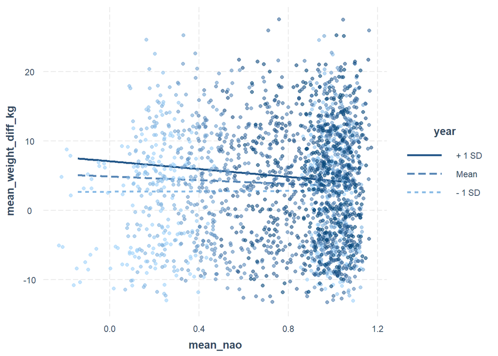

```r
#plot variation interaction of year and mean NAO on weight change
interact_plot(mod6.3,
              pred = mean_nao,
              modx = year,
              plot.points = TRUE,
             # point.shape = TRUE, # different shape for differennt levels of the moderator
             # partial.residuals = TRUE,
              jitter = 0.1) # if two data points are on top one another, this moves them apart by little)
```

**Figure 20.2** - Investigating the interactions between NAO and year.

```r
#slope analysis of year.
  ss <- sim_slopes(mod6.3,
           pred = mean_nao,
           modx = year,
           modx.values = c(1990, 2000,2010,2020),
           johnson_neyman = FALSE,
           )

ss
```

```
## SIMPLE SLOPES ANALYSIS
##
## Slope of mean_nao when year = 1990.00:
##
##   Est.   S.E.   t val.      p
## ------ ------ -------- ------
##   0.61   0.74     0.82   0.41
##
## Slope of mean_nao when year = 2000.00:
##
##    Est.   S.E.   t val.      p
## ------- ------ -------- ------
##   -0.83   0.72    -1.15   0.25
##
## Slope of mean_nao when year = 2010.00:
##
##    Est.   S.E.   t val.      p
## ------- ------ -------- ------
##   -2.28   1.19    -1.92   0.06
##
## Slope of mean_nao when year = 2020.00:
##
##    Est.   S.E.   t val.      p
## ------- ------ -------- ------
##   -3.72   1.80    -2.07   0.04
```

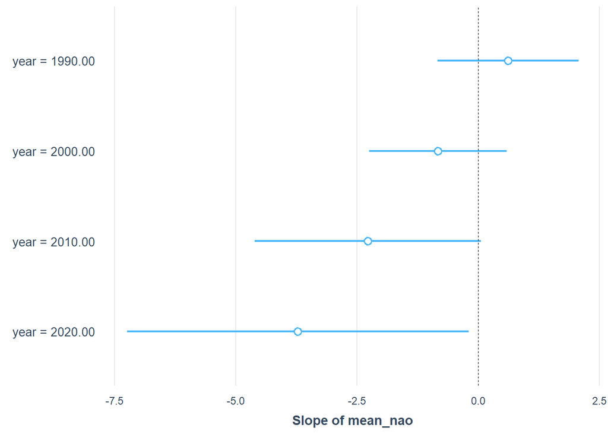

```r
plot(ss)
```

**figure 20.3** - A slope analysis of year (Model 6.3) The P-value decreases each decade.

## 6.10 Mass Data

```r
#check between yearly grouped data and individual data sets because the grouping action greatly reduced the amount of data points.

#weight and sex
glm_mass_X1 <- glm(weight_diff_kg ~ sex,
                   data = mass_data_clean,
                   family = "gaussian")


#weight, sex and age
glm_mass_X2 <- glm(weight_diff_kg ~ sex + age,
                   data = mass_data_clean,
                   family = "gaussian")


# weight with an interaction between sex and age.
glm_mass_cross <- glm(weight_diff_kg ~ sex * age,
                   data = mass_data_clean,
                   family = "gaussian")
```

```r
compare_performance(mod3,glm_mass_cross) %>% kable()
```

| Name | Model | AIC | AIC_wt | AICc | AICc_wt | BIC | BIC_wt | R2 | RMSE | Sigma |
| --- | --- | --- | --- | --- | --- | --- | --- | --- | --- | --- |
| mod3 | glm | 10032.83 | 1 | 10032.87 | 1 | 10066.83 | 1 | 0.9069592 | 2.526313 | 2.529275 |
| glm_mass_cross | glm | 37519.47 | 0 | 37519.48 | 0 | 37553.24 | 0 | 0.7212367 | 4.676227 | 4.677704 |

# 7 Generalised linear mixed models (GLMMs)

- Random effects (potential)
  - site
  - number of babies
  - age/ year

## 7.1 GLMM transformation

```r
#re-wrangle the grouped data to include a wider set of variables to investigate random effects.

grp_mass_predictors_v2 <-  mass_data %>%
  #re_grouping,adding in site and n_babies as factors
  dplyr::group_by( year, age, sex, site = as.factor(site), n_babies = as.factor(n_babies )) %>%
  dplyr::filter(!is.na(weight)) %>%   #remove NAs
  dplyr::rename(age_yrs = age) %>% #add in units of measure.
  summarise(mean_weight_diff_kg = mean(weight))
# join in NAO type data.

grp_mass_pred_NAO_GLMM <- dplyr::left_join(grp_mass_predictors_v2, seasonal_nao_data,
                                           by = c("year"= "year"))


head(grp_mass_pred_NAO_GLMM) %>% kable()
```

| year | age_yrs | sex | site | n_babies | mean_weight_diff_kg | nao_type | mean_nao |
| --- | --- | --- | --- | --- | --- | --- | --- |
| 1980 | 0 | f | 1 | 0 | 5.439987 | not_summer_NAO | 1.0074401 |
| 1980 | 0 | f | 1 | 0 | 5.439987 | summer_NAO | 0.0063377 |
| 1980 | 0 | f | 1 | 1 | 5.082990 | not_summer_NAO | 1.0074401 |
| 1980 | 0 | f | 1 | 1 | 5.082990 | summer_NAO | 0.0063377 |
| 1980 | 0 | f | 2 | 1 | 1.297862 | not_summer_NAO | 1.0074401 |
| 1980 | 0 | f | 2 | 1 | 1.297862 | summer_NAO | 0.0063377 |

## 7.2 Fitting GLMMs -

```r
#### Random intercepts  #####


#site as a random effect
m_mod1 <- glmmTMB(mean_weight_diff_kg ~ mean_nao + sex * age_yrs +
                    (1|site), #random intercept effects
                  data=grp_mass_pred_NAO_GLMM,
                  family="gaussian")



# number of babies as a random effect
m_mod2 <-  glmmTMB(mean_weight_diff_kg ~ mean_nao + sex * age_yrs +
                   (1|n_babies), #random intercept effects
                   data=grp_mass_pred_NAO_GLMM,
                   family="gaussian")

# age as a random effect
m_mod3 <- glmmTMB(mean_weight_diff_kg ~ mean_nao + sex +
                    (1|age_yrs ), #random intercept effects
                  data=grp_mass_pred_NAO_GLMM,
                  family="gaussian")

# year as a random effect
m_mod5 <- glmmTMB(mean_weight_diff_kg ~ mean_nao + sex * age_yrs +
                    (1|year), #random intercept effects
                  data=grp_mass_pred_NAO_GLMM,
                  family="gaussian")

# year as a random effect with no age predictor
m_mod5.1 <- glmmTMB(mean_weight_diff_kg ~ mean_nao + sex +
                    (1|year), #random intercept effects
                  data=grp_mass_pred_NAO_GLMM,
                  family="gaussian")
```

## 7.3 GLMM outputs

```r
# there is very little difference between the marginal and conditional values for these two predictors.

a <-  MuMIn::r.squaredGLMM(m_mod1)
b <-  MuMIn::r.squaredGLMM(m_mod2)

rbind(a,b) %>% kable()
```

| R2m | R2c |
| --- | --- |
| 0.7647006 | 0.7653626 |
| 0.7642751 | 0.7644283 |

Site and number of babies are not a random effect.

```r
c <-  MuMIn::r.squaredGLMM(m_mod5)
d <- MuMIn::r.squaredGLMM(m_mod5.1)

rbind(c,d) %>% kable()
```

| R2m | R2c |
| --- | --- |
| 0.7641861 | 0.7679387 |
| 0.5848306 | 0.6103214 |

Year has the highest variance suggesting a random effect on weight change.

## 7.4 Nesting

```r
# year as a random effect nested with age.
m_mod5.2 <- glmmTMB(mean_weight_diff_kg ~ mean_nao + sex +
                    (1|year/age_yrs), #random intercept effects
                  data=grp_mass_pred_NAO_GLMM,
                  family="gaussian")


MuMIn::r.squaredGLMM(m_mod5.2)
```

```
##            R2m       R2c
## [1,] 0.5571929 0.7935843
```

```r
# this nicely compares models glmm model results.
(parcomp <- cbind(m_mod2=unlist(fixef(m_mod2)),
                  m_mod5.1=unlist(fixef(m_mod5.1)),
                  m_mod5.2=unlist(fixef(m_mod5.2)))) %>% kable()
```

|  | m_mod2 | m_mod5.1 | m_mod5.2 |
| --- | --- | --- | --- |
| cond.(Intercept) | 4.0641946 | 8.3027730 | 10.1833905 |
| cond.mean_nao | -0.0553765 | 0.1300674 | 0.0763923 |
| cond.sexm | -13.3739696 | -13.3878205 | -13.3371927 |
| cond.age_yrs | 0.8951576 | 3.3961122 | 2.8015009 |
| cond.sexm:age_yrs | 0.0082211 | 8.3027730 | 10.1833905 |
| disp.(Intercept) | 2.8845107 | 0.1300674 | 0.0763923 |

```r
anova(m_mod1, m_mod5.1, m_mod5.2)
```

```
## Data: grp_mass_pred_NAO_GLMM
## Models:
## m_mod5.1: mean_weight_diff_kg ~ mean_nao + sex + (1 | year), zi=~0, disp=~1
## m_mod5.2: mean_weight_diff_kg ~ mean_nao + sex + (1 | year/age_yrs), zi=~0, disp=~1
## m_mod1: mean_weight_diff_kg ~ mean_nao + sex * age_yrs + (1 | site), zi=~0, disp=~1
##          Df   AIC   BIC logLik deviance   Chisq Chi Df Pr(>Chisq)
## m_mod5.1  5 55576 55612 -27783    55566
## m_mod5.2  6 51740 51783 -25864    51728 3837.92      1  < 2.2e-16 ***
## m_mod1    7 50909 50958 -25447    50895  833.85      1  < 2.2e-16 ***
## ---
## Signif. codes:  0 '***' 0.001 '**' 0.01 '*' 0.05 '.' 0.1 ' ' 1
```

```r
summary(m_mod5.2)
```

```
##  Family: gaussian  ( identity )
## Formula:          mean_weight_diff_kg ~ mean_nao + sex + (1 | year/age_yrs)
## Data: grp_mass_pred_NAO_GLMM
##
##      AIC      BIC   logLik deviance df.resid
##  51740.5  51783.0 -25864.2  51728.5     8890
##
## Random effects:
##
## Conditional model:
##  Groups       Name        Variance  Std.Dev.
##  age_yrs:year (Intercept) 1.886e+01 4.342928
##  year         (Intercept) 4.134e-06 0.002033
##  Residual                 1.647e+01 4.058244
## Number of obs: 8896, groups:  age_yrs:year, 552; year, 41
##
## Dispersion estimate for gaussian family (sigma^2): 16.5
##
## Conditional model:
##              Estimate Std. Error z value Pr(>|z|)
## (Intercept)  10.18339    0.23122   44.04   <2e-16 ***
## mean_nao      0.07639    0.15422    0.50     0.62
## sexm        -13.33719    0.08930 -149.36   <2e-16 ***
## ---
## Signif. codes:  0 '***' 0.001 '**' 0.01 '*' 0.05 '.' 0.1 ' ' 1
```

Year nested with age has a more varied maginal and conditional.

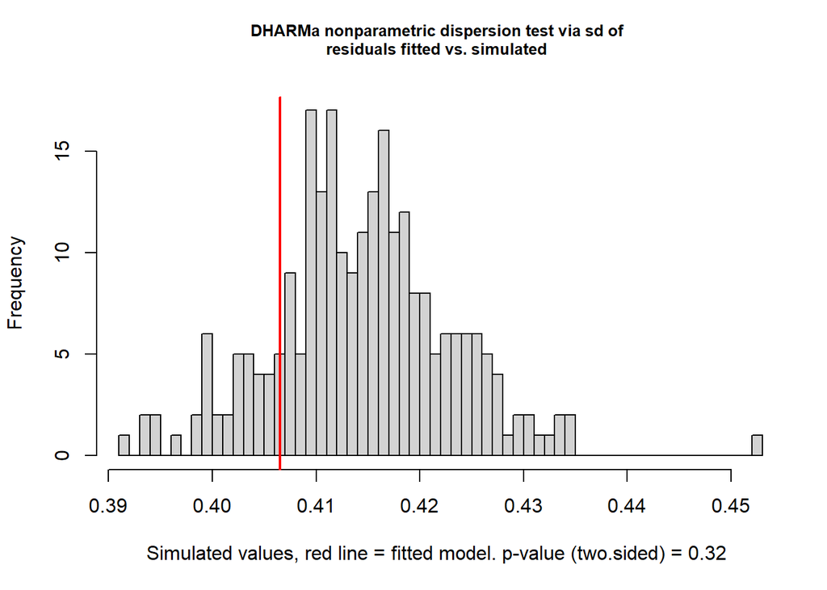

```
##
##  DHARMa nonparametric dispersion test via sd of residuals fitted vs.
##  simulated
##
## data:  simulationOutput
## dispersion = 0.98104, p-value = 0.32
## alternative hypothesis: two.sided
```

```r
testDispersion(m_mod5.1)
```

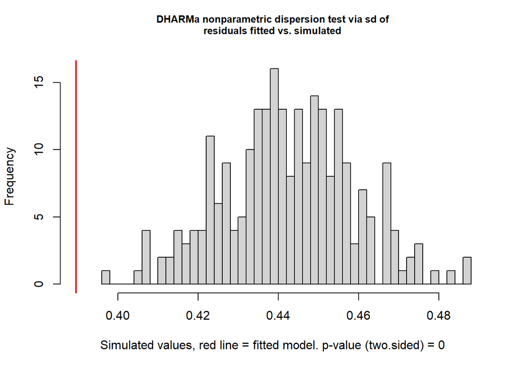

```
##
##  DHARMa nonparametric dispersion test via sd of residuals fitted vs.
##  simulated
##
## data:  simulationOutput
## dispersion = 0.88036, p-value < 2.2e-16
## alternative hypothesis: two.sided
```

```r
testDispersion(m_mod5.2)
```

## 7.5 Plotting model

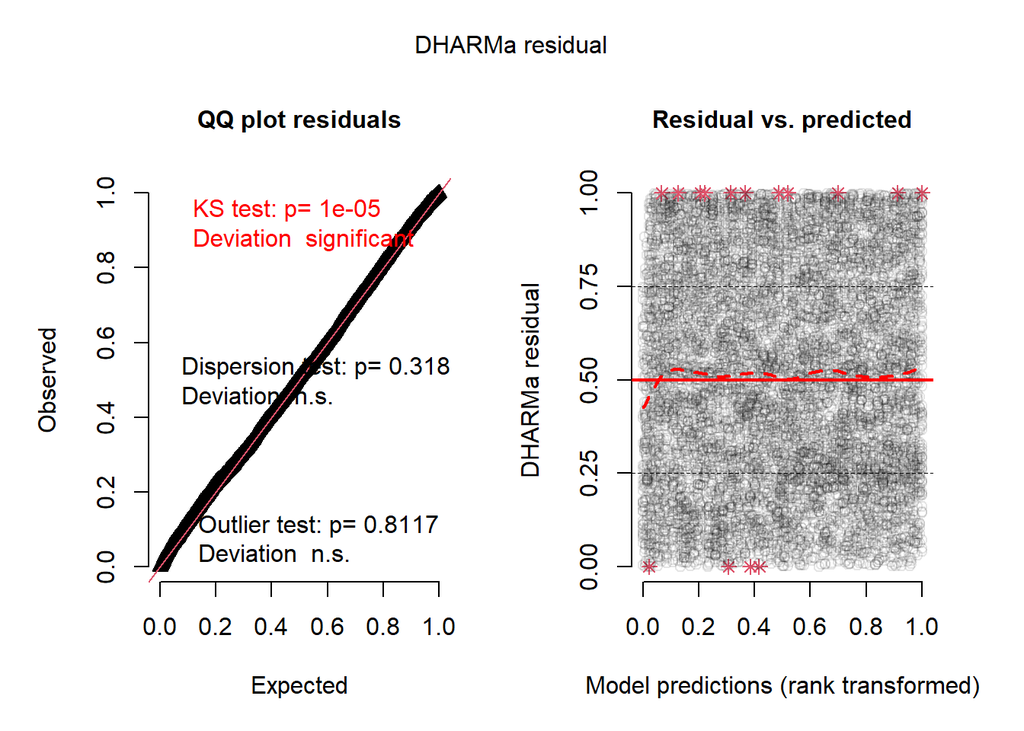

```r
m_mod5.1_sim <- simulateResiduals(m_mod5.1, n = 1000)
m_mod5.2_sim <- simulateResiduals(m_mod5.2, n = 1000)

plot(m_mod5.1_sim)
```

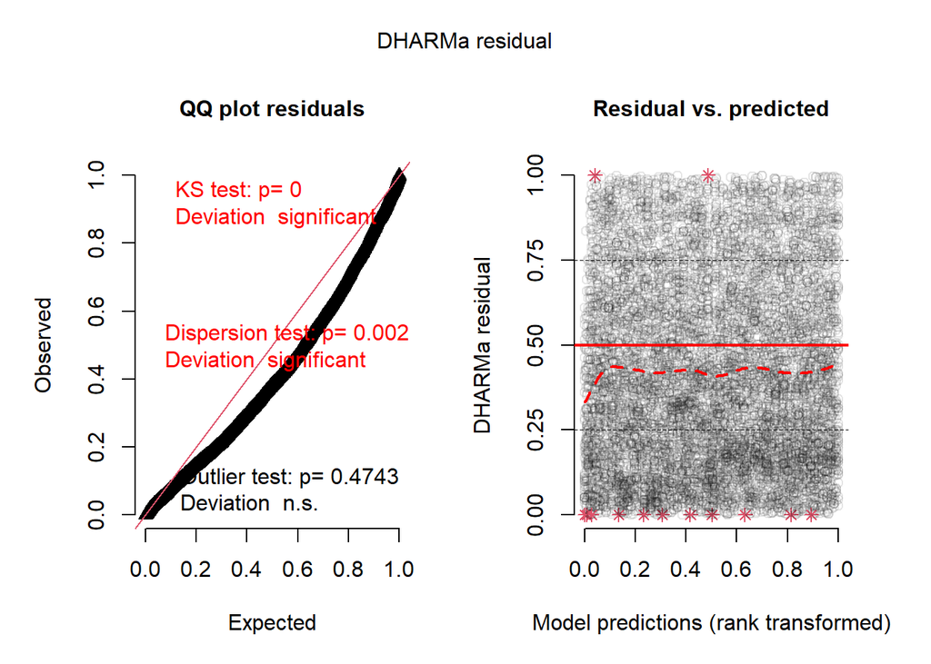

```r
plot(m_mod5.2_sim)
```

**Figure 21.** - The age nesting causes a significant dispersion result which could indicate a mis-specified model.

### 7.5.1 coefficients

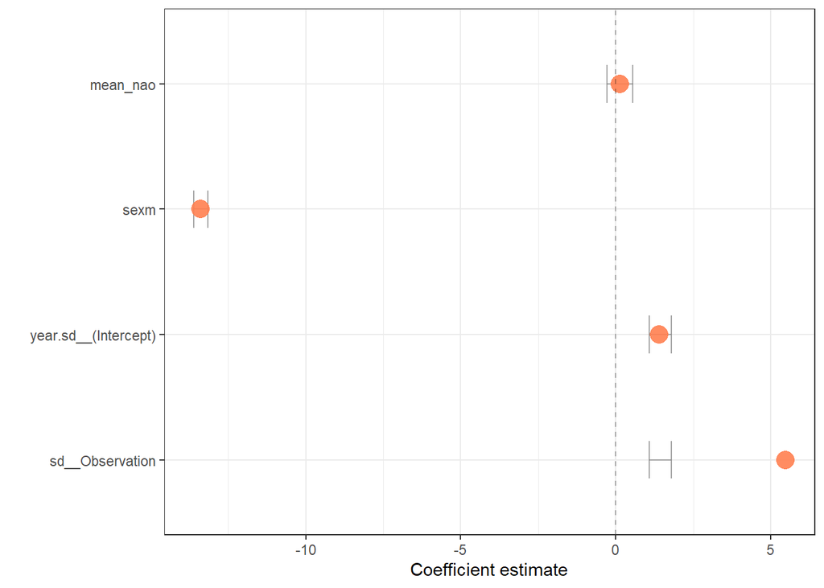

```r
## reshape the outputs of the model into a tidy format:
tidy_mod5.1 <- broom.mixed::tidy(m_mod5.1, conf.int = TRUE) %>%
  ##clean up the random effect names
  mutate(term=ifelse(grepl("sd__(Int",term,
                           fixed=TRUE),
                     paste(group,term,sep="."),
                     term))


##filter and sort the data
sorted_tidy_mod5.1 <-
  tidy_mod5.1 %>%
  filter(term!="(Intercept)") %>%
  mutate(term=factor(term, levels = rev(term)))

##plot it out
ggplot(sorted_tidy_mod5.1, aes(x=estimate, y=term)) +
  geom_errorbar(aes(xmin=conf.low, xmax=conf.high),
                width=0.3,
                col="grey50",
                alpha=0.7) +
  geom_point(col="coral", size=5, alpha=0.9) +
  geom_vline(xintercept=0, lty="dashed", alpha=0.3) +
  theme_bw() +
  ylab("") +
  xlab("Coefficient estimate")
```

**Figure 22.** Visualisations for the model coefficients.

## 7.6 Yearly temporal correlations

```r
# Individuals have been sampled over a long period which can lead to artificial correlations.
# temporal correlations model - year

m_mod4.1 <- glmmTMB(mean_weight_diff_kg ~ mean_NAO +
                      (1|year), #random intercept effects)
                    data=grouped_mass_NAO, # time must be unique so predictors removed.
                  family="gaussian")

summary(m_mod4.1)
```

```
##  Family: gaussian  ( identity )
## Formula:          mean_weight_diff_kg ~ mean_NAO + (1 | year)
## Data: grouped_mass_NAO
##
##      AIC      BIC   logLik deviance df.resid
##    145.7    152.6    -68.9    137.7       37
##
## Random effects:
##
## Conditional model:
##  Groups   Name        Variance Std.Dev.
##  year     (Intercept) 0.02289  0.1513
##  Residual             1.66213  1.2892
## Number of obs: 41, groups:  year, 41
##
## Dispersion estimate for gaussian family (sigma^2): 1.66
##
## Conditional model:
##             Estimate Std. Error z value Pr(>|z|)
## (Intercept)   -8.379      1.960  -4.274 1.92e-05 ***
## mean_NAO      11.107      2.238   4.963 6.94e-07 ***
## ---
## Signif. codes:  0 '***' 0.001 '**' 0.01 '*' 0.05 '.' 0.1 ' ' 1
```

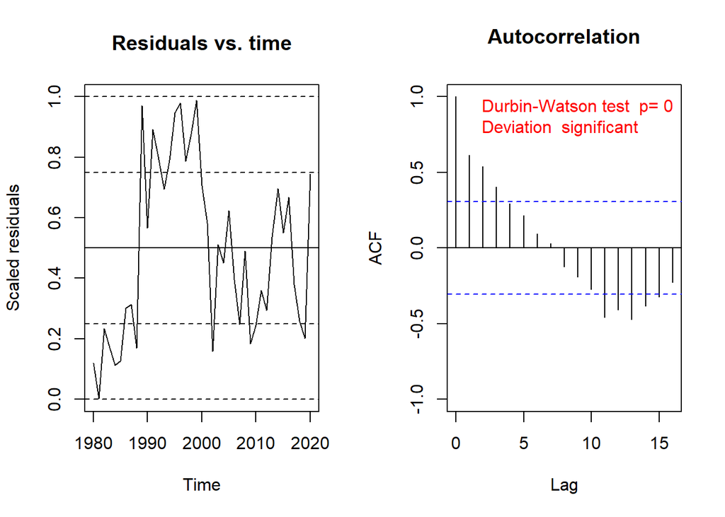

```
##
##  Durbin-Watson test
##
## data:  simulationOutput$scaledResiduals ~ 1
## DW = 0.70969, p-value = 2.209e-06
## alternative hypothesis: true autocorrelation is not 0
```

```r
m_mod4.1_sim <- simulateResiduals(m_mod4.1, n = 1000)


testTemporalAutocorrelation(m_mod4.1_sim,
                            time = grouped_mass_NAO$year,
                            plot = TRUE)
```

**Figure 23.** - temporal auto correlation analysis. Fitting a simplified model with weight against mean NAO shows fluctuations in residuals overtime, with a p-value of < 0.05. This analysis has used year as a link between mass and NAO and the most recent years are showing a rise.

## 7.7 Predicted vs observed.

```r
#create df for model 5.1 observed vs predicted
fit_glmm_5.1 <- data.frame("predicted"= predict(m_mod5.1,data = grp_mass_pred_NAO_GLMM, type = "response"),
                        "observed" = grp_mass_pred_NAO_GLMM$mean_weight_diff_kg)
# create df for model 5.2 observed vs predicted
fit_glmm_5.2 <- data.frame("predicted"= predict(m_mod5.2,data = grp_mass_pred_NAO_GLMM, type = "response"),
                       "observed" = grp_mass_pred_NAO_GLMM$mean_weight_diff_kg)
# create df for model 5.2 observed vs predicted
fit_glmm_4.1 <- data.frame("predicted"= predict(m_mod4.1,data = grouped_mass_NAO, type = "response"),
                       "observed" = grouped_mass_NAO$mean_weight_diff_kg)
```

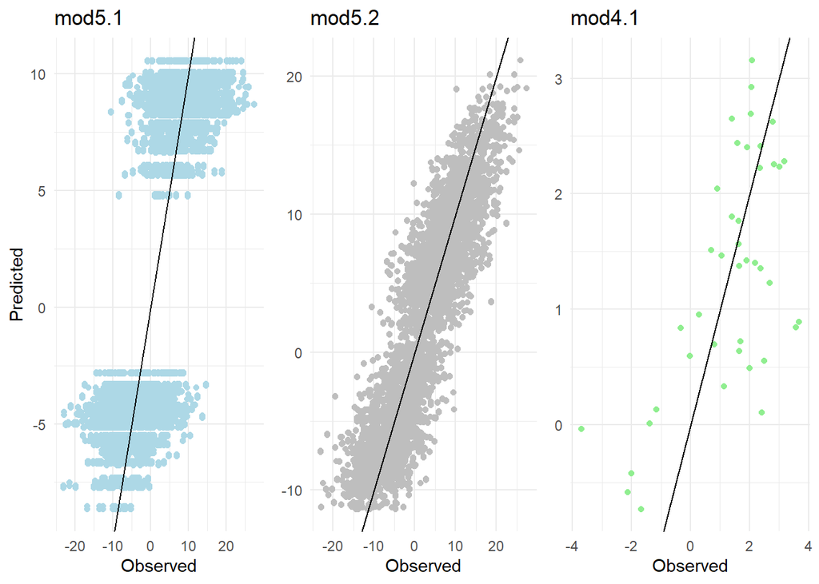

```r
## Model 5.1 plot the predicted against the observed
glmm_mod5.1 <- ggplot(fit_glmm_5.1, aes(x = observed,
                       y = predicted)) +
  geom_point(col="lightblue") +
  geom_abline(slope = 1) +
  theme_minimal() +
  xlab("Observed") +
  ylab("Predicted") +
  ggtitle("mod5.1")



##Model 5.2 plot the predicted against the observed
glmm_mod5.2 <- ggplot(fit_glmm_5.2, aes(x = observed,
                       y = predicted)) +
  geom_point(col="grey") +
  geom_abline(slope = 1) +
  theme_minimal() +
  xlab("Observed") +
  ylab("Predicted") +
   ggtitle("mod5.2") +
  theme(axis.title.y =element_blank()) # remove dup axis



##Model 4.1 plot the predicted against the observed
glmm_mod4.1 <- ggplot(fit_glmm_4.1, aes(x = observed,
                       y = predicted)) +
  geom_point(col="lightgreen") +
  geom_abline(slope = 1) +
  theme_minimal() +
  xlab("Observed") +
  ylab("Predicted") +
   ggtitle("mod4.1") +
  theme(axis.title.y =element_blank()) # remove dup axis



grid.arrange(glmm_mod5.1, glmm_mod5.2, glmm_mod4.1, nrow = 1)
```

**Figure 18** Predicted vs observed GLMMs.

# 8 Discussion

To conclude, a positive relationship between weight difference and mean NAO has been identified (Figure 9). Sex and age are predictors of weight with males presenting a decrease in response (Figure 7). Figure 13 shows how this relationship correlates higher within the sNAO period.

There is evidence to reject the null hypothesis and claim that NAO is a variable that is linked to weight difference in *Oves ares*.

However, a single causal relationship between sNAO and weight change is not appropriate.

Year has been estimated as a random effect on weight, but a significant temporal auto correlation is overestimating the relationships. (Figure 23)

Further investigations could include weight transformations (cube roots) to remove negative values and apply different models or adding an age range category.